# NYPD Shooting Incident

L.Stopponi

2026-04-03

## R Markdown

I loaded the necessary library, then I found the dataset about NYPD Shooting Incident at this link: https://data.cityofnewyork.us/api/views/833y-fsy8/rows.csv?accessType=DOWNLOAD. The dataset contains a list of every shooting incident that occurred in NYC going back to 2006 through the end of the previous calendar year. The data was manually extracted every quarter and reviewed by the Office of Management Analysis and Planning before being posted on the NYPD website. Each record represents a shooting incident in NYC and includes information about the event, the location and time of occurrence. Then I loaded it, and called head() and glimpse() on the data to get its specifics, using the following code:

```r
library(tidyverse)
url_nypd <- "https://data.cityofnewyork.us/api/views/833y-fsy8/rows.csv?accessType=DOWNLOAD"
nypd_data <- read_csv(url_nypd)
head(nypd_data)
```

```
## # A tibble: 6 × 21
##   INCIDENT_KEY OCCUR_DATE OCCUR_TIME BORO     LOC_OF_OCCUR_DESC PRECINCT
##          <dbl> <chr>      <time>     <chr>    <chr>                <dbl>
## 1    231974218 08/09/2021 01:06      BRONX    <NA>                    40
## 2    177934247 04/07/2018 19:48      BROOKLYN <NA>                    79
## 3    255028563 12/02/2022 22:57      BRONX    OUTSIDE                 47
## 4     25384540 11/19/2006 01:50      BROOKLYN <NA>                    66
## 5     72616285 05/09/2010 01:58      BRONX    <NA>                    46
## 6     85875439 07/22/2012 21:35      BRONX    <NA>                    42
## # ℹ 15 more variables: JURISDICTION_CODE <dbl>, LOC_CLASSFCTN_DESC <chr>,
## #   LOCATION_DESC <chr>, STATISTICAL_MURDER_FLAG <lgl>, PERP_AGE_GROUP <chr>,
## #   PERP_SEX <chr>, PERP_RACE <chr>, VIC_AGE_GROUP <chr>, VIC_SEX <chr>,
## #   VIC_RACE <chr>, X_COORD_CD <dbl>, Y_COORD_CD <dbl>, Latitude <dbl>,
## #   Longitude <dbl>, Lon_Lat <chr>
```

```r
glimpse(nypd_data)
```

```
## Rows: 29,744
## Columns: 21
## $ INCIDENT_KEY            <dbl> 231974218, 177934247, 255028563, 25384540, 726…
## $ OCCUR_DATE              <chr> "08/09/2021", "04/07/2018", "12/02/2022", "11/…
## $ OCCUR_TIME              <time> 01:06:00, 19:48:00, 22:57:00, 01:50:00, 01:58…
## $ BORO                    <chr> "BRONX", "BROOKLYN", "BRONX", "BROOKLYN", "BRO…
## $ LOC_OF_OCCUR_DESC       <chr> NA, NA, "OUTSIDE", NA, NA, NA, NA, NA, NA, NA,…
## $ PRECINCT                <dbl> 40, 79, 47, 66, 46, 42, 71, 69, 75, 69, 40, 42…
## $ JURISDICTION_CODE       <dbl> 0, 0, 0, 0, 0, 2, 0, 2, 0, 0, 0, 2, 0, 0, 2, 0…
## $ LOC_CLASSFCTN_DESC      <chr> NA, NA, "STREET", NA, NA, NA, NA, NA, NA, NA, …
## $ LOCATION_DESC           <chr> NA, NA, "GROCERY/BODEGA", "PVT HOUSE", "MULTI …
## $ STATISTICAL_MURDER_FLAG <lgl> FALSE, TRUE, FALSE, TRUE, TRUE, FALSE, TRUE, F…
## $ PERP_AGE_GROUP          <chr> NA, "25-44", "(null)", "UNKNOWN", "25-44", "18…
## $ PERP_SEX                <chr> NA, "M", "(null)", "U", "M", "M", NA, NA, "M",…
## $ PERP_RACE               <chr> NA, "WHITE HISPANIC", "(null)", "UNKNOWN", "BL…
## $ VIC_AGE_GROUP           <chr> "18-24", "25-44", "25-44", "18-24", "<18", "18…
## $ VIC_SEX                 <chr> "M", "M", "M", "M", "F", "M", "M", "M", "M", "…
## $ VIC_RACE                <chr> "BLACK", "BLACK", "BLACK", "BLACK", "BLACK", "…
## $ X_COORD_CD              <dbl> 1006343.0, 1000082.9, 1020691.0, 985107.3, 100…
## $ Y_COORD_CD              <dbl> 234270.0, 189064.7, 257125.0, 173349.8, 247502…
## $ Latitude                <dbl> 40.80967, 40.68561, 40.87235, 40.64249, 40.845…
## $ Longitude               <dbl> -73.92019, -73.94291, -73.86823, -73.99691, -7…
## $ Lon_Lat                 <chr> "POINT (-73.92019278899994 40.80967347200004)"…
```

## Tidying and Transforming data

In this step, I cleaned the dataset by removing unnecessary columns such as (“Latitude”, “Longitude”, “Lon_Lat”, “X_COORD_CD”, “Y_COORD_CD”). I also worked on the date and run some checks to make sure that the data is consistent and didn’t have issues. During the consistency check, I found that LOC_OF_OCCUR_DESC, LOC_CLASSFCTN_DESC, and LOCATION_DESC had over 50% missing values (NAs). Therefore, I decided to remove these columns as well from the dataset, as they are not representative enough for a reliable analysis. In the PERP_AGE_GROUP column, both null and unknown appear, so I unified them, setting both of them to NA. Then as asked by the exercise I changed the appropriate variables (“BORO”, “PRECINT”, “STATISTICAL_MURDER_FLAG”, “PERP AGE GROUP”, “PERP_SEX”, “PERP_RACE”, “VIC_AGE_GROUP”, “VIC_RACE”) to factors.

```r
library(lubridate)

nypd_data <- nypd_data %>%
  #Removing columns not relevant or with too many NA values
  select(-c(X_COORD_CD, Y_COORD_CD, Latitude, Longitude, Lon_Lat,
            LOC_OF_OCCUR_DESC, LOC_CLASSFCTN_DESC, LOCATION_DESC)) %>%

  #Transforming data and unifying missing values in PERP_AGE_GROUP
  mutate(OCCUR_DATE = mdy(OCCUR_DATE),
         PERP_AGE_GROUP = na_if(PERP_AGE_GROUP, "(null)"),
         PERP_AGE_GROUP = na_if(PERP_AGE_GROUP, "UNKNOWN")) %>%

  #Transforming appropriate variables in factors
  mutate(across(c(BORO,
                  PRECINCT,
                  STATISTICAL_MURDER_FLAG,
                  PERP_AGE_GROUP, PERP_SEX, PERP_RACE,
                  VIC_AGE_GROUP, VIC_SEX, VIC_RACE),
                  as.factor))
summary(nypd_data)
```

```
##   INCIDENT_KEY         OCCUR_DATE           OCCUR_TIME
##  Min.   :  9953245   Min.   :2006-01-01   Min.   :00:00:00.000000
##  1st Qu.: 67321140   1st Qu.:2009-10-29   1st Qu.:03:30:45.000000
##  Median :109291972   Median :2014-03-25   Median :15:15:00.000000
##  Mean   :133850951   Mean   :2014-10-31   Mean   :12:46:10.874798
##  3rd Qu.:214741917   3rd Qu.:2020-06-29   3rd Qu.:20:44:00.000000
##  Max.   :299462478   Max.   :2024-12-31   Max.   :23:59:00.000000
##
##             BORO          PRECINCT     JURISDICTION_CODE
##  BRONX        : 8834   75     : 1680   Min.   :0.0000
##  BROOKLYN     :11685   73     : 1561   1st Qu.:0.0000
##  MANHATTAN    : 3977   67     : 1288   Median :0.0000
##  QUEENS       : 4426   44     : 1159   Mean   :0.3181
##  STATEN ISLAND:  822   79     : 1073   3rd Qu.:0.0000
##                        47     : 1048   Max.   :2.0000
##                        (Other):21935   NA's   :2
##  STATISTICAL_MURDER_FLAG PERP_AGE_GROUP    PERP_SEX              PERP_RACE
##  FALSE:23979             18-24  : 6630   (null): 1628   BLACK         :12323
##  TRUE : 5765             25-44  : 6342   F     :  461   WHITE HISPANIC: 2667
##                          <18    : 1805   M     :16845   UNKNOWN       : 1838
##                          45-64  :  775   U     : 1500   (null)        : 1628
##                          65+    :   67   NA's  : 9310   BLACK HISPANIC: 1487
##                          (Other):    5                  (Other)       :  491
##                          NA's   :14120                  NA's          : 9310
##  VIC_AGE_GROUP   VIC_SEX                             VIC_RACE
##  <18    : 3081   F: 2891   AMERICAN INDIAN/ALASKAN NATIVE:   13
##  1022   :    1   M:26841   ASIAN / PACIFIC ISLANDER      :  478
##  18-24  :10677   U:   12   BLACK                         :20999
##  25-44  :13563             BLACK HISPANIC                : 2930
##  45-64  : 2118             UNKNOWN                       :   72
##  65+    :  236             WHITE                         :  741
##  UNKNOWN:   68             WHITE HISPANIC                : 4511
```

## Visualizations and Analysis

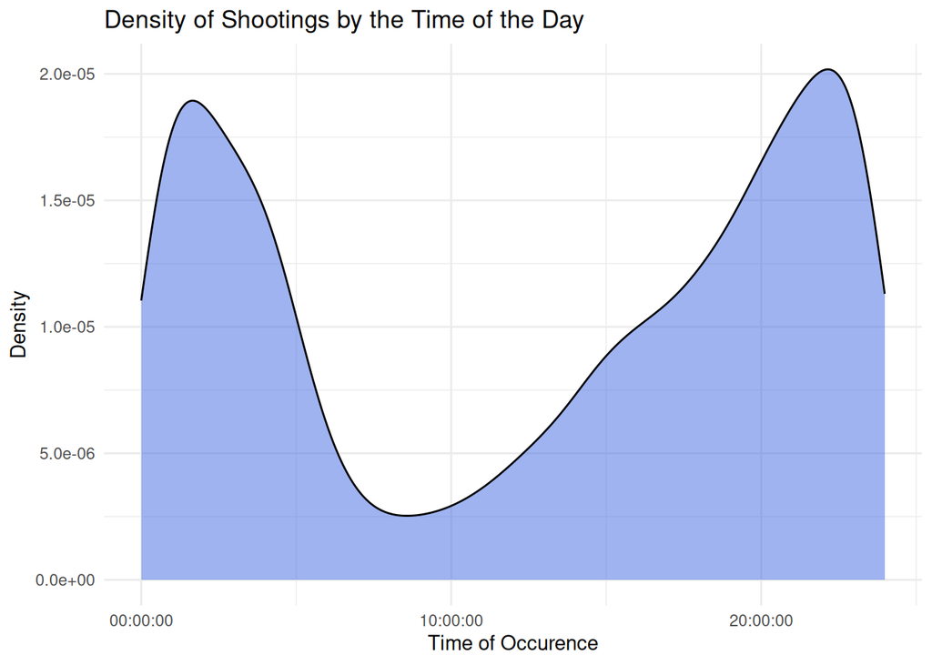

```r
#Plot 1: Density of Shootings by the Time of the Day
ggplot(nypd_data, aes(x=OCCUR_TIME)) +
  geom_density(fill = "royalblue", alpha = 0.5) +
  labs(title = "Density of Shootings by the Time of the Day",
       x = "Time of Occurence",
       y = "Density") +
    theme_minimal()
```

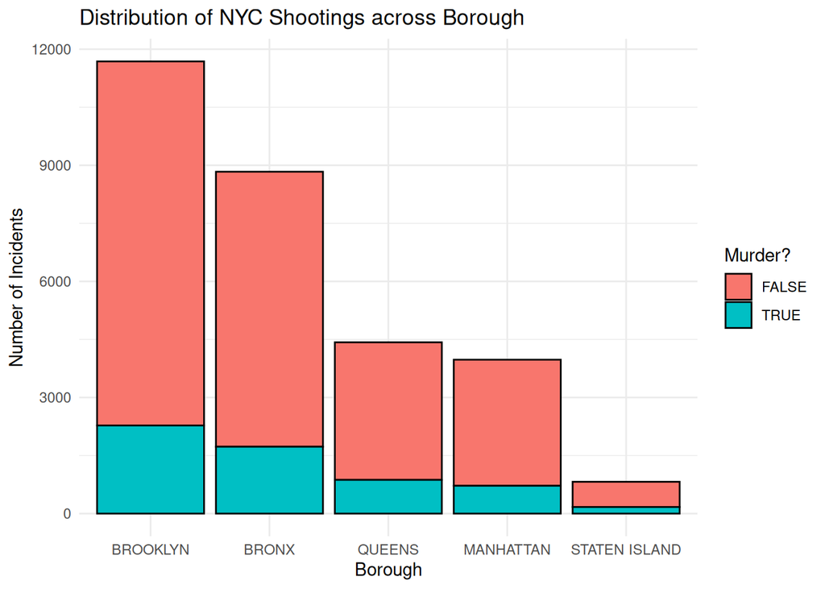

```r
#Plot 2: Number of incidents distributed for borough
ggplot(nypd_data, aes(x = fct_infreq(BORO), fill = STATISTICAL_MURDER_FLAG)) +
  geom_bar(color = "black") +
  labs(title = "Distribution of NYC Shootings across Borough",
  x = "Borough",
  y = "Number of Incidents",
  fill = "Murder?") +
theme_minimal()
```

```r
#Table, Lethality rate by Borough
nypd_lethality <- nypd_data %>%
  group_by(BORO) %>%
  summarize(
    Total_Shootings = n(),
    Total_Murders = sum(STATISTICAL_MURDER_FLAG == TRUE),
    Lethality_Rate = (Total_Murders / Total_Shootings) * 100
  ) %>%
  arrange(desc(Lethality_Rate))

nypd_lethality
```

```
## # A tibble: 5 × 4
##   BORO          Total_Shootings Total_Murders Lethality_Rate
##   <fct>                   <int>         <int>          <dbl>
## 1 STATEN ISLAND             822           170           20.7
## 2 QUEENS                   4426           871           19.7
## 3 BRONX                    8834          1728           19.6
## 4 BROOKLYN                11685          2277           19.5
## 5 MANHATTAN                3977           719           18.1
```

```r
#Building a logistic regression model
murder_model <- glm(STATISTICAL_MURDER_FLAG ~ BORO + OCCUR_TIME,
                    data = nypd_data,
                    family = "binomial")
summary(murder_model)
```

```
##
## Call:
## glm(formula = STATISTICAL_MURDER_FLAG ~ BORO + OCCUR_TIME, family = "binomial",
##     data = nypd_data)
##
## Coefficients:
##                     Estimate Std. Error z value Pr(>|z|)
## (Intercept)       -1.429e+00  3.511e-02 -40.702   <2e-16 ***
## BOROBROOKLYN      -4.921e-03  3.557e-02  -0.138   0.8900
## BOROMANHATTAN     -9.642e-02  4.917e-02  -1.961   0.0499 *
## BOROQUEENS         8.861e-03  4.640e-02   0.191   0.8485
## BOROSTATEN ISLAND  7.061e-02  9.021e-02   0.783   0.4338
## OCCUR_TIME         3.206e-07  4.832e-07   0.663   0.5070
## ---
## Signif. codes:  0 '***' 0.001 '**' 0.01 '*' 0.05 '.' 0.1 ' ' 1
##
## (Dispersion parameter for binomial family taken to be 1)
##
##     Null deviance: 29251  on 29743  degrees of freedom
## Residual deviance: 29245  on 29738  degrees of freedom
## AIC: 29257
##
## Number of Fisher Scoring iterations: 4
```

## Bias

There are several sources of Bias that may affect the integrity of this dataset. **The Reporting Bias**: the dataset only includes the incidents reported or discovered by the NYPD. Shootings that did not result in a 911 call or hospital visit may be missing, potentially underrepresenting violence in certain neighborhoods. **Missing data**: An important part of the perpetrator demographics was labeled as “Unknown” or “null”. Relying on this incomplete data to draw conclusions about offender profiles could lead to inaccurate social profiling. **Survivor Bias**: The Lethality Rate is based on the Statistical_murder_flag. Improvements in emergency medical response over the decades might decrease this flag’s frequency, even if the number of shooting incidents remains high.**Personal Bias**: Having followed general news reports about NYC, I ha preconceived notions of which boroughs might be “more dangerous”. To mitigate this, I avoided making assumptions based on raw counts alone.